# HW04

2022-11-22

# Prerequisites

```r
library(tidyverse)
library(modelr)
library(nycflights13)
library(lubridate)
options(na.action = na.warn)
```

# Textbook 19.3.1

## Problem 1

```r
f1 <- function(string, prefix) {
  substr(string, 1, nchar(prefix)) == prefix
}
f2 <- function(x) {
  if (length(x) <= 1) return(NULL)
  x[-length(x)]
}
f3 <- function(x, y) {
  rep(y, length.out = length(x))
}
```

```r
f1('dislike', 'dis')
```

```
## [1] TRUE
```

```r
f1('dislike', 'in')
```

```
## [1] FALSE
```

```r
f2(1:8)
```

```
## [1] 1 2 3 4 5 6 7
```

```r
f3(seq(1,8), c(1,5))
```

```
## [1] 1 5 1 5 1 5 1 5
```

```r
have_prefix <- function(string, prefix) {
  substr(string, 1, nchar(prefix)) == prefix
}
remove_last <- function(x) {
  if (length(x) <= 1) return(NULL)
  x[-length(x)]
}
rep_len <- function(x, y) {
  rep(y, length.out = length(x))
}
```

snake_case로 이름을 붙혔습니다.

# Textbook 19.4.4

## Problem 1

if는 하나의 조건에 대해서만 검사가 가능하다. 즉, 벡터 연산이 불가능하다. 반면, ifelse()는 각 요소별 조건검사가 가능하다.

```r
test1 <- c(1, 10, 100)
try(
  if(test1 > 50){
  print('pass')
})
```

```
## Error in if (test1 > 50) { : the condition has length > 1
```

```r
ifelse(test1 > 50, 'pass', 'fail')
```

```
## [1] "fail" "fail" "pass"
```

```r
test2 <- 100
if(test2 == 100){
  print('wow!')
}
```

```
## [1] "wow!"
```

```r
ifelse(test2 == 100, 'wow!', 'cheer up~')
```

```
## [1] "wow!"
```

```r
test3 <- c('happy', 'sad', 'angry')
try(for (i in 1:3) {
if (test3[i] == 'happy'){
  print('lucky day~!')
} else{
  print("don't worry")
}})
```

```
## [1] "lucky day~!"
## [1] "don't worry"
## [1] "don't worry"
```

```r
ifelse(test3 == 'happy', 'lucky day~!', "don't worry")
```

```
## [1] "lucky day~!" "don't worry" "don't worry"
```

## Problem 6

```r
func_swithch <- function(x) {
switch(x,
  a = ,
  b = "ab",
  c = ,
  d = "cd"
)
}
```

```r
func_swithch("a")
```

```
## [1] "ab"
```

```r
func_swithch("b")
```

```
## [1] "ab"
```

```r
func_swithch("c")
```

```
## [1] "cd"
```

```r
func_swithch("d")
```

```
## [1] "cd"
```

a, b를 인자로 받을 때는 “ab”를 c, d를 인자로 받을 때는 “cd”를 반환한다.

```r
func_swithch("e")
func_swithch("A")
```

switch()내부에 조건을 지정하지 않은 인수가 입력되면 어떤 값도 반환하지 않는다. switch함수는 조건과 그에 따른 할당 값을 미리 지정하면, 입력된 값이 조건에 부합할 경우 설정한 할당값으로 변환하는 함수이다.

# Textbook 19.5.5

## Problem 4

“pearson”은 피어슨 상관계수를, “kendall”은 켄달의 타우 상관계수를, “spearman”은 스피어먼 상관계수를 의미한다. default는 pearson이다.

# Textbook 20.3.5

## Problem 2

```r
near
```

```
## function (x, y, tol = .Machine$double.eps^0.5)
## {
##     abs(x - y) < tol
## }
## <bytecode: 0x000001c79a5132e8>
## <environment: namespace:dplyr>
```

x와 y의 차가 tol값 보다 작다면 True를, 작지 않다면 False를 반환한다. 부동소수점인 두 수 벡터가 같은지 확인할 때 사용한다.

# Textbook 20.5.4

## Problem 1

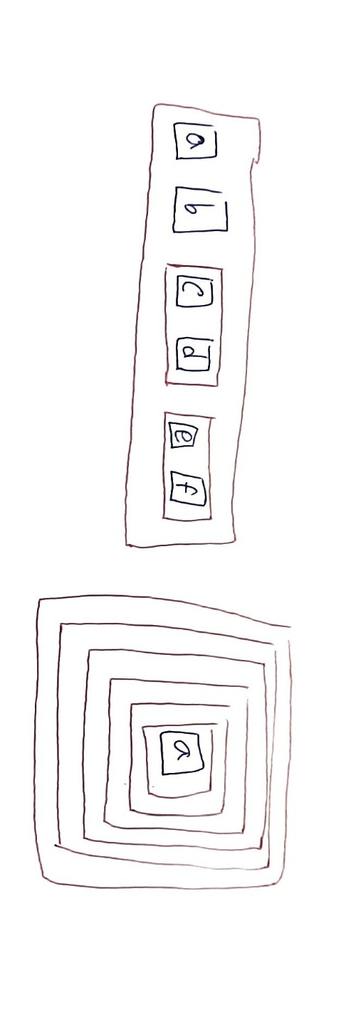

img

# Textbook 20.7.4

## Problem 2

```r
#tibble(
#  a = 1:5,
#  b = 1:3,
#  c = c('x', 'y', 'z')
#)
```

길이가 다른 columns을 사용하려하면 tibble이 만들어지지 않는다. 오직 사이즈가 하나인 벡터만 재활용가능하다.

```r
tibble(
  a = 1:5,
  b = 1,
  c = c('x')
)
```

```
## # A tibble: 5 × 3
##       a     b c
##   <int> <dbl> <chr>
## 1     1     1 x
## 2     2     1 x
## 3     3     1 x
## 4     4     1 x
## 5     5     1 x
```

## Problem 3

```r
tibble(
  a = 1:5,
  b = list(1, 'b', list(1:3), 2, 5),
  c = list('x')
)
```

```
## # A tibble: 5 × 3
##       a b          c
##   <int> <list>     <list>
## 1     1 <dbl [1]>  <chr [1]>
## 2     2 <chr [1]>  <chr [1]>
## 3     3 <list [1]> <chr [1]>
## 4     4 <dbl [1]>  <chr [1]>
## 5     5 <dbl [1]>  <chr [1]>
```

길이를 같게 하거나, 길이가 1인 리스트를 만든다면 가능하다. 하지만 그 값이 표시되지는 않는다.

# Textbook 21.2.1

## Problem 2

```r
str_c(letters, collapse = "")
```

```
## [1] "abcdefghijklmnopqrstuvwxyz"
```

```r
x <- sample(100)
sd(x)
```

```
## [1] 29.01149
```

```r
x <- runif(100)
cumsum(x)
```

```
##   [1]  0.8040281  1.4786227  1.5506939  1.6936118  1.7041305  2.2480841
##   [7]  3.0297800  3.7179682  4.2292843  4.5361275  5.4775770  6.3451217
##  [13]  7.2118644  7.9788607  8.2469122  8.4964676  9.0871755  9.9621576
##  [19] 10.1003594 10.9632217 11.0676084 11.3709238 11.6815931 11.9523178
##  [25] 12.3496248 12.9642072 13.1315805 13.5285235 14.4537906 14.4983757
##  [31] 14.6452636 14.7578066 15.2690600 16.2638238 16.5120457 17.1763532
##  [37] 17.9527387 18.4994152 18.6913067 18.8609323 19.0226350 19.1768362
##  [43] 20.0582830 20.1088281 20.2538940 20.6611268 21.3274781 21.6122761
##  [49] 21.8348179 22.7783183 23.7263327 24.3391314 25.0869602 25.1915355
##  [55] 25.7248471 25.8347722 26.7894811 27.7189717 28.1493915 28.6979987
##  [61] 29.6417101 29.9607460 30.5929005 31.0916459 31.4440731 32.4147437
##  [67] 32.5555142 32.9600077 33.6875497 34.6808765 35.0348925 35.2936363
##  [73] 36.2025180 37.1539495 37.2188108 37.9822745 38.1102340 38.4604015
##  [79] 38.8367678 39.3713668 40.2920099 40.9890461 41.3439654 41.3620112
##  [85] 41.9707760 42.7681184 43.3217274 43.3648746 43.7217398 44.6541656
##  [91] 45.4365724 45.5698345 46.3741344 47.1703135 47.3760224 47.5814337
##  [97] 48.1044581 48.7819946 49.7753716 50.4317825
```

# Textbook 21.3.5

## Problem 3

```r
show_means <- function(df) {
  out <- vector("logical", length(df))
  for (i in seq_along(df)) {
    out[[i]] <- is.numeric(df[[i]])
  }
  df_col <- df[out]

  means <- vector("list", length(df_col))
  names(means) <- names(df_col)
  for (i in seq_along(df_col)){
    means[[i]] <- round(mean(df_col[[i]], na.rm = TRUE), digits = 2)
  }

  means_names <- names(means)
  max_names <-  max(str_length(means_names)) - str_length(means_names) + 1

  cat( str_c(means_names, ":", str_dup(" ", max_names), means), fill = TRUE)
}

show_means(iris)
```

```
## Sepal.Length: 5.84 Sepal.Width:  3.06 Petal.Length: 3.76 Petal.Width:  1.2
```

# Textbook 21.4.1

## Problem 1

’apply(X, MARGIN, FUN, …)’는 다음과 같이 쓰이는데, X가 행렬이나 데이터프레임 같은 이차원 객체라면, 행또는 열로 FUN을 적용합니다.

```r
X <- data.frame(a = c(1:5), b = c(6:10), c = c(11:15))
```

```r
apply(X, 1, mean)
```

```
## [1]  6  7  8  9 10
```

MARGIN = 1이면, 행에 대해 apply한다.

```r
apply(X, 2, mean)
```

```
##  a  b  c
##  3  8 13
```

MARGIN = 2이면, 열에 대해 apply한다.

# Textbook 21.5.3

## Problem 1

```r
map_dbl(mtcars, mean)
```

```
##        mpg        cyl       disp         hp       drat         wt       qsec
##  20.090625   6.187500 230.721875 146.687500   3.596563   3.217250  17.848750
##         vs         am       gear       carb
##   0.437500   0.406250   3.687500   2.812500
```

```r
map_chr(nycflights13::flights, typeof)
```

```
##           year          month            day       dep_time sched_dep_time
##      "integer"      "integer"      "integer"      "integer"      "integer"
##      dep_delay       arr_time sched_arr_time      arr_delay        carrier
##       "double"      "integer"      "integer"       "double"    "character"
##         flight        tailnum         origin           dest       air_time
##      "integer"    "character"    "character"    "character"       "double"
##       distance           hour         minute      time_hour
##       "double"       "double"       "double"       "double"
```

```r
map_int(iris, n_distinct)
```

```
## Sepal.Length  Sepal.Width Petal.Length  Petal.Width      Species
##           35           23           43           22            3
```

```r
x <- c(-10, 0, 10, 100)
map(x, ~rnorm(n = 10, mean = x))
```

```
## [[1]]
##  [1]  -8.05054247  -1.90153073   9.48430520  98.72853362 -11.05691725
##  [6]   1.07241023   9.58281912 101.80032135  -9.52670947  -0.07673368
##
## [[2]]
##  [1] -11.078310  -1.134014   9.987642  99.333710  -8.533754   1.401848
##  [7]  10.780381 100.092820  -9.747065  -1.324234
##
## [[3]]
##  [1] -11.5241412   0.6450771  10.6191299 101.9607753  -9.1224755   0.6566566
##  [7]  10.9117616  99.1036078  -8.0525630  -1.2226376
##
## [[4]]
##  [1]  -9.8689085   1.3828732  10.4147762 101.2139845 -11.0173878  -1.0044094
##  [7]  10.6039170 100.0112434  -9.8932524  -0.8786076
```

# Textbook 21.9.3

## Problem 3

```r
col_sum3 <- function(df, f) {
  is_num <- sapply(df, is.numeric)
  df_num <- df[, is_num]
  sapply(df_num, f)
}
```

```r
df <- tibble(
  x = 1:3,
  y = 3:1,
  z = c("a", "b", "c")
)

# OK
col_sum3(df, mean)
```

```
## x y
## 2 2
```

```r
# Has problems: don't always return numeric vector
col_sum3(df[1:2], mean)
```

```
## x y
## 2 2
```

```r
col_sum3(df[1], mean)
```

```
## x
## 2
```

```r
#col_sum3(df[0], mean)
```

sapply 때문에 버그가 발생합니다. 없는 열이 선택되면 빈 numeric 벡터를 반환하는게 아니라, 빈 리스트를 반홥합니다. 그리고 리스트는 []로 사용할 수 없기 때문에 버그가 발생합니다.

```r
sapply(df[0], is.numeric)
```

```
## named list()
```

# Textbook 23.4.5

## Problem 3

```r
mod1 <- lm(y ~ x1 + x2, data = sim3)
mod2 <- lm(y ~ x1 * x2, data = sim3)
```

```r
mod1
```

```
##
## Call:
## lm(formula = y ~ x1 + x2, data = sim3)
##
## Coefficients:
## (Intercept)           x1          x2b          x2c          x2d
##      1.8717      -0.1967       2.8878       4.8057       2.3596
```

```r
model_matrix(y ~ x1 + x2, data = sim3)
```

```
## # A tibble: 120 × 5
##    `(Intercept)`    x1   x2b   x2c   x2d
##            <dbl> <dbl> <dbl> <dbl> <dbl>
##  1             1     1     0     0     0
##  2             1     1     0     0     0
##  3             1     1     0     0     0
##  4             1     1     1     0     0
##  5             1     1     1     0     0
##  6             1     1     1     0     0
##  7             1     1     0     1     0
##  8             1     1     0     1     0
##  9             1     1     0     1     0
## 10             1     1     0     0     1
## # … with 110 more rows
```

```r
mod1_model <- function(data){
   mutate(data,
    x2b = as.numeric(x2 == "b"),
    x2c = as.numeric(x2 == "c"),
    x2d = as.numeric(x2 == "d"),
    `(Intercept)` = 1
  ) %>%
    select(`(Intercept)`, x1, x2b, x2c, x2d)
}
```

```r
mod1_model(sim3)
```

```
## # A tibble: 120 × 5
##    `(Intercept)`    x1   x2b   x2c   x2d
##            <dbl> <int> <dbl> <dbl> <dbl>
##  1             1     1     0     0     0
##  2             1     1     0     0     0
##  3             1     1     0     0     0
##  4             1     1     1     0     0
##  5             1     1     1     0     0
##  6             1     1     1     0     0
##  7             1     1     0     1     0
##  8             1     1     0     1     0
##  9             1     1     0     1     0
## 10             1     1     0     0     1
## # … with 110 more rows
```

```r
mod2
```

```
##
## Call:
## lm(formula = y ~ x1 * x2, data = sim3)
##
## Coefficients:
## (Intercept)           x1          x2b          x2c          x2d       x1:x2b
##     1.30124     -0.09302      7.06938      4.43090      0.83455     -0.76029
##      x1:x2c       x1:x2d
##     0.06815      0.27728
```

```r
model_matrix(y ~ x1 * x2, data = sim3)
```

```
## # A tibble: 120 × 8
##    `(Intercept)`    x1   x2b   x2c   x2d `x1:x2b` `x1:x2c` `x1:x2d`
##            <dbl> <dbl> <dbl> <dbl> <dbl>    <dbl>    <dbl>    <dbl>
##  1             1     1     0     0     0        0        0        0
##  2             1     1     0     0     0        0        0        0
##  3             1     1     0     0     0        0        0        0
##  4             1     1     1     0     0        1        0        0
##  5             1     1     1     0     0        1        0        0
##  6             1     1     1     0     0        1        0        0
##  7             1     1     0     1     0        0        1        0
##  8             1     1     0     1     0        0        1        0
##  9             1     1     0     1     0        0        1        0
## 10             1     1     0     0     1        0        0        1
## # … with 110 more rows
```

```r
mod2_model <- function(data) {
  mutate(data,
    x2b = as.numeric(x2 == "b"),
    x2c = as.numeric(x2 == "c"),
    x2d = as.numeric(x2 == "d"),
    `(Intercept)` = 1,
    `x1:x2b` = x1*x2b,
    `x1:x2c` = x1*x2c,
    `x1:x2d` = x1*x2d,
  ) %>%
    select(`(Intercept)`, x1, x2b, x2c, x2d, `x1:x2b`,  `x1:x2c`, `x1:x2d`)
}
```

```r
mod2_model(sim3)
```

```
## # A tibble: 120 × 8
##    `(Intercept)`    x1   x2b   x2c   x2d `x1:x2b` `x1:x2c` `x1:x2d`
##            <dbl> <int> <dbl> <dbl> <dbl>    <dbl>    <dbl>    <dbl>
##  1             1     1     0     0     0        0        0        0
##  2             1     1     0     0     0        0        0        0
##  3             1     1     0     0     0        0        0        0
##  4             1     1     1     0     0        1        0        0
##  5             1     1     1     0     0        1        0        0
##  6             1     1     1     0     0        1        0        0
##  7             1     1     0     1     0        0        1        0
##  8             1     1     0     1     0        0        1        0
##  9             1     1     0     1     0        0        1        0
## 10             1     1     0     0     1        0        0        1
## # … with 110 more rows
```

# Textbook 24.2.3

## Problem 2

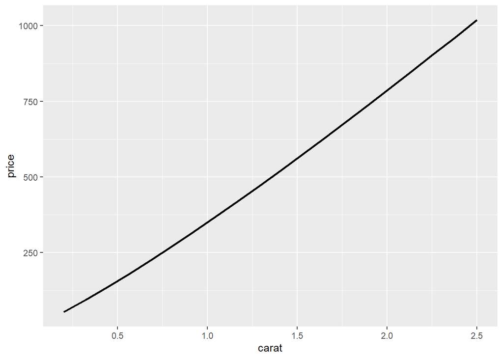

```r
diamonds2 <- diamonds %>%
  filter(carat <= 2.5) %>%
  mutate(lprice = log(price), lcarat = log(carat))

mod_diamond <- lm(lprice ~ lcarat, data = diamonds2)

grid <- diamonds2 %>%
  data_grid(carat = seq_range(carat, 20)) %>%
  mutate(lcarat = log(carat)) %>%
  add_predictions(mod_diamond, "lprice") %>%
  mutate(price = 2 ^ lprice)

ggplot(diamonds2, aes(carat, price)) + geom_line(data = grid, size = 1)
```

둘 사이엔 선형적 관계가 존재하는 듯 보인다. carat의 1%증가는 가격의 1% 증가와 관련 있다.

# Textbook 24.3.5

## Problem 2

```r
daily <- flights %>%
  mutate(date = make_date(year, month, day)) %>%
  group_by(date) %>%
  summarise(n = n())

daily <- daily %>%
  mutate(wday = wday(date, label = TRUE))

mod <- lm(n ~ wday, data = daily)

daily <- daily %>%
  add_residuals(mod)
```

```r
top_n(daily, 3, resid)
```

```
## # A tibble: 3 × 4
##   date           n wday  resid
##   <date>     <int> <ord> <dbl>
## 1 2013-11-30   857 토    112.
## 2 2013-12-01   987 일     95.5
## 3 2013-12-28   814 토     69.4
```

세 날들은 추수감사절 및 새해와 가까운 주말이다. 따라서 다른 연도에 대해서도 두 명절과 가까운 주말들로 일반화가능할 것이라 생각한다.

# Extra question(s)

## 1

### a

```r
data(iris)
 swidth.versicolor <- vector(mode = "double", length = 0)
 for (i in seq_len(nrow(iris)) ) {
         if (iris$Species[i]=="versicolor") {
                 swidth.versicolor <- c(swidth.versicolor, iris$Sepal.Width[i])
         }
 }
swidth.versicolor
```

```
##  [1] 3.2 3.2 3.1 2.3 2.8 2.8 3.3 2.4 2.9 2.7 2.0 3.0 2.2 2.9 2.9 3.1 3.0 2.7 2.2
## [20] 2.5 3.2 2.8 2.5 2.8 2.9 3.0 2.8 3.0 2.9 2.6 2.4 2.4 2.7 2.7 3.0 3.4 3.1 2.3
## [39] 3.0 2.5 2.6 3.0 2.6 2.3 2.7 3.0 2.9 2.9 2.5 2.8
```

```r
data(iris)
swidth.versicolor <- as.vector(unlist(subset(iris, iris$Species == "versicolor")["Sepal.Width"]))
swidth.versicolor
```

```
##  [1] 3.2 3.2 3.1 2.3 2.8 2.8 3.3 2.4 2.9 2.7 2.0 3.0 2.2 2.9 2.9 3.1 3.0 2.7 2.2
## [20] 2.5 3.2 2.8 2.5 2.8 2.9 3.0 2.8 3.0 2.9 2.6 2.4 2.4 2.7 2.7 3.0 3.4 3.1 2.3
## [39] 3.0 2.5 2.6 3.0 2.6 2.3 2.7 3.0 2.9 2.9 2.5 2.8
```

### b

```r
 data(iris)
 head(iris$Sepal.Length[iris$Species])
```

```
## [1] 5.1 5.1 5.1 5.1 5.1 5.1
```

```r
str(iris$Species)
```

```
##  Factor w/ 3 levels "setosa","versicolor",..: 1 1 1 1 1 1 1 1 1 1 ...
```

species는 factor형 자료로 setosa versicolor virginica의 레벨이 각 1 2 3 이다.

```r
typeof(iris$Species)
```

```
## [1] "integer"
```

그리고 타입을 보아도 “integer”로 나온다.

```r
head(iris$Species)
```

```
## [1] setosa setosa setosa setosa setosa setosa
## Levels: setosa versicolor virginica
```

`iris$Species`의 head는 모두 setosa로 1이다. `head(iris$Sepal.Length[iris$Species])`는 1번째 행의 sepal.length값을 6번 보여주는 것과 같아진다.

## 2

### 3

각각 4, 16, 8, 64가 나올 것이다.

```r
power <- function(exponent) {
   function(x) {
     x ^ exponent
   }
 }

 square <- power(2)
 square(2)
```

```
## [1] 4
```

```r
 square(4)
```

```
## [1] 16
```

```r
 cube <- power(3)
 cube(2)
```

```
## [1] 8
```

```r
 cube(4)
```

```
## [1] 64
```

`power()`를 통해서는 함수의 첫번째 인자인 exponent를 지정하고 `square()`을 통해서는 두번째 인자인 x를 지정한다.

### b

1과 2를 vector로 반환할것이다.

```r
 j <- function(x) {
   y <- 2
   function() {
     c(x, y)
   }
 }
 k <- j(1)
```

j(1)을 통해 x = 1을 할당하였고 y는 함수 내부에서 할당되어있으니 `k()`는 1과 2를 반환한다.